# 11 - Reševanje PDE z Galerkinovo metodo

Matematično-fizikalni praktikum, avgust 2024  
Luka Skeledžija, 28201079

## Uvod

Pri opisu enakomernega laminarnega toka viskozne in nestisljive tekočine po dolgi ravni cevi pod vplivom stalnega tlačnega gradienta $p^{\prime}$ se Navier-Stokesova enačba poenostavi v Poissonovo enačbo

\begin{equation*} \nabla^2 v = \Delta v = - \frac{p^\prime}{\eta}\>, \end{equation*}

kjer je $v$ vzdolžna komponenta hitrosti, odvisna samo od koordinat preseka cevi, $\eta$ pa je viskoznost tekočine. Enačbo rešujemo v notranjosti preseka cevi, medtem ko je ob stenah hitrost tekočina enaka nič. Za pretok velja Poiseuillov zakon

\begin{equation*} \Phi = \int_S v dS = C\,\frac{p' S^2}{ 8\pi\eta} \>, \end{equation*}

kjer je koeficient $C$ odvisen samo od oblike preseka cevi ($C=1$ za okroglo cev). Določili bomo koeficient za polkrožno cev z radijem $R$. V novih spremenljivkah $\xi=r/R$ in $u=v \eta/(p^\prime R^2)$ se problem glasi

\begin{equation*} \Delta u(\xi,\phi) = -1 \>,\qquad u(\xi=1,\phi)=u(\xi,0)=u(\xi,\phi=\pi)=0 \>, \end{equation*}

\begin{equation*} C = 8\pi \iint \frac{u(\xi,\phi)\,\xi d \xi d \phi}{ (\pi/2)^2} \>. \end{equation*}

Če poznamo lastne funkcije diferencialnega operatorja za določeno geometrijo\footnote{Spomni se na primer na vodikov atom v sferični geometriji, kjer smo imeli $\widehat{L}^2 Y_{lm}(\theta,\phi) = \hbar^2 l(l+1) Y_{lm}(\theta,\phi)$ in $\widehat{L}_z Y_{lm}(\theta,\phi) = m \hbar Y_{lm}(\theta,\phi)$.} se reševanje parcialnih diferencialnih enačb včasih lahko prevede na razvoj po lastnih funkcijah. Da bi se izognili računanju lastnih (za ta primer Besselovih) funkcij in njihovih ničel, ki jih potrebujemo v razvoju, lahko zapišemo aproksimativno rešitev kot linearno kombinacijo nekih poskusnih (*trial*) funkcij \begin{equation} \tilde{u}(\xi,\phi) = \sum\limits_{i=1}^N a_i \Psi_i(\xi,\phi), \end{equation} za katere ni nujno, da so ortogonalne, pač pa naj zadoščajo robnim pogojem, tako da jim bo avtomatično zadoščala tudi zgornja vsota. Ta pristop nam pride prav v kompleksnejših geometrijah, ko je uporabnost lastnih funkcij izključena in potrebujemo robustnejši pristop. Približna funkcija $\tilde{u}$ seveda ne zadosti Poissonovi enačbi: preostane majhna napaka $\varepsilon$ \begin{equation*} \Delta \tilde{u}(\xi,\phi) + 1 = \varepsilon(\xi,\phi) \>. \end{equation*} Pri metodi Galerkina zahtevamo, da je napaka ortogonalna na vse poskusne funkcije $\Psi_i$, \begin{equation*} (\varepsilon,\Psi_i) = 0 \>, \qquad i = 1,2,\dots, N \>. \end{equation*} V splošnem bi lahko zahtevali tudi ortogonalnost $\varepsilon$ na nek drug sistem utežnih (*weight*) oziroma testnih (*test*) funkcij $\Psi_i$. Metoda Galerkina je poseben primer takih metod (*Methods of Weighted Residuals*) z izbiro $\Psi_i = \Psi_i$. Omenjena izbira vodi do sistema enačb za koeficiente $a_i$ \begin{equation} \sum_{j=1}^N A_{ij} a_j = b_i\>, \qquad i = 1,2,\dots, N \>, \end{equation}

$$ A_{ij} = (\Delta \Psi_j,\Psi_i) \>, \qquad b_i = (-1,\Psi_i) \>, $$ tako da je koeficient za pretok enak

\begin{equation*} C =-\frac{32}{ \pi} \sum_{ij} b_i A_{ij}^{-1} b_j \>. \end{equation*}

Za kotni del poskusne funkcije obdržimo eksaktne funkcije $\sin((2m+1)\phi)$, Besselove funkcije za radialni del pa nadomestimo s preprostejšimi funkcijami $\xi^{2m+1}(1-\xi)^n$.

## Določanje konstante $C$

Tokrat je pot do rešitve za koeficient C relativno preprosta. Ustvariti moramo bločno diagonalno matriko $\textbf{A}$ in vektor $\vec{b}$. Tedaj lahko s pomočjo `np.linalg.solve` rešimo sistem

$$ \textbf{A} \vec{a} = \vec{b},$$

in izrazimo vektor $\vec{a}$. Z njim lahko sedaj izračunamo vrednost $C$ po formuli

$$ C = \frac{-32}{\pi} \, \vec{b} \cdot \vec{a} $$

Za velikost matrike $\textbf{A} = (100, 100) $ smo določili vrednost:

$C = 0.7577218731$

Preverimo še kaj se zgodi, če variiramo parametre $N$ in $M$. Vidimo, da se vrednost relativno hitro približuje refernčnemu $C$ pri $N, M = 100$. Časovna zahtevnost tudi postopoma narašča.

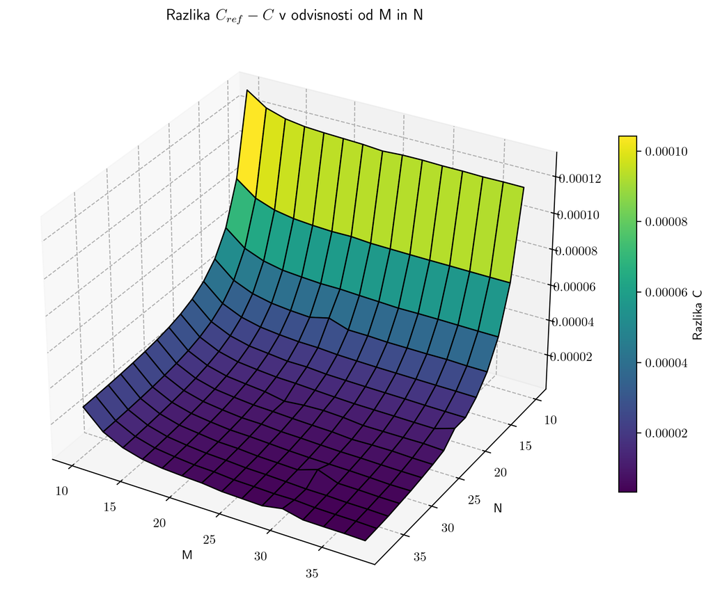

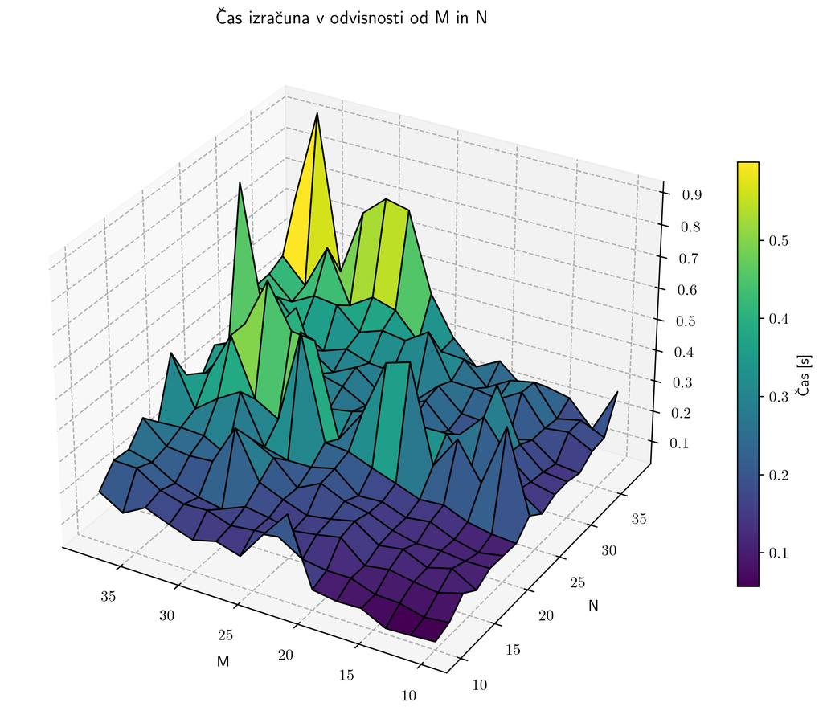

V naslednjem koraku bomo vrednosti $M$ in $N$ spreminjali skupaj. Glede na prejšnje grafe za velike M in N obnašanje v smeri M in N ni zelo bistveno drugačno. Zanimala nas bo razlika $C_M - C_{M-5}$ kot nekakšna mera konvergence. Opazimo, da je sprememba vrednosti $C$ po vrednosti $M + 60$ in več, zelo majhna. Iz tega zaključimo, da je konvergenca relativno hitra. Se pa tudi ustrezno podaljša čas izračuna.

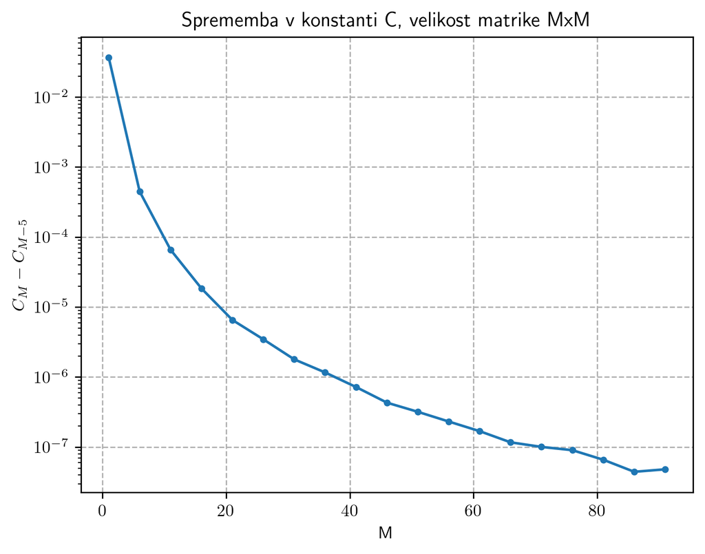

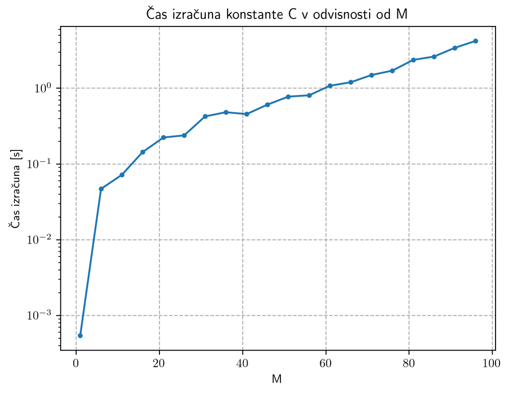

## Pretok v cevi

Narišimo še kako približno bi izgledal pretok vode v naši cevi. To naredimo s pomočjo poskusnih funkcij - velja, da je rešitev problema kar linearna kombinacija $\psi_{mn}$:

$$ u(\xi, \phi) = \sum_{m,n} a_{mn} \, \psi_{mn} (\xi, \phi) $$

Posamezne lastne funkcije izgledajo takole:

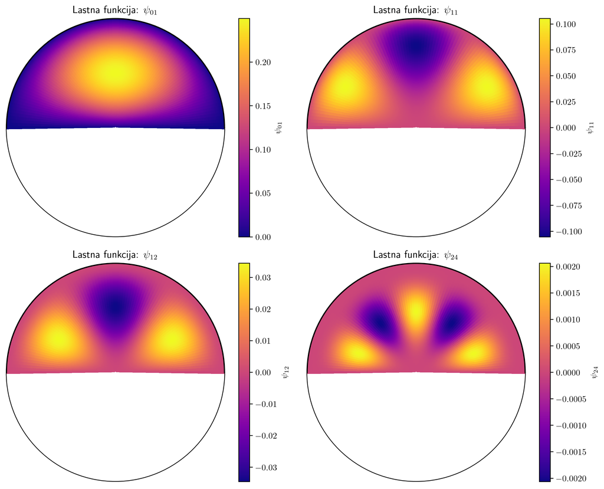

Linearna kombinacija za naš problem pa tako:

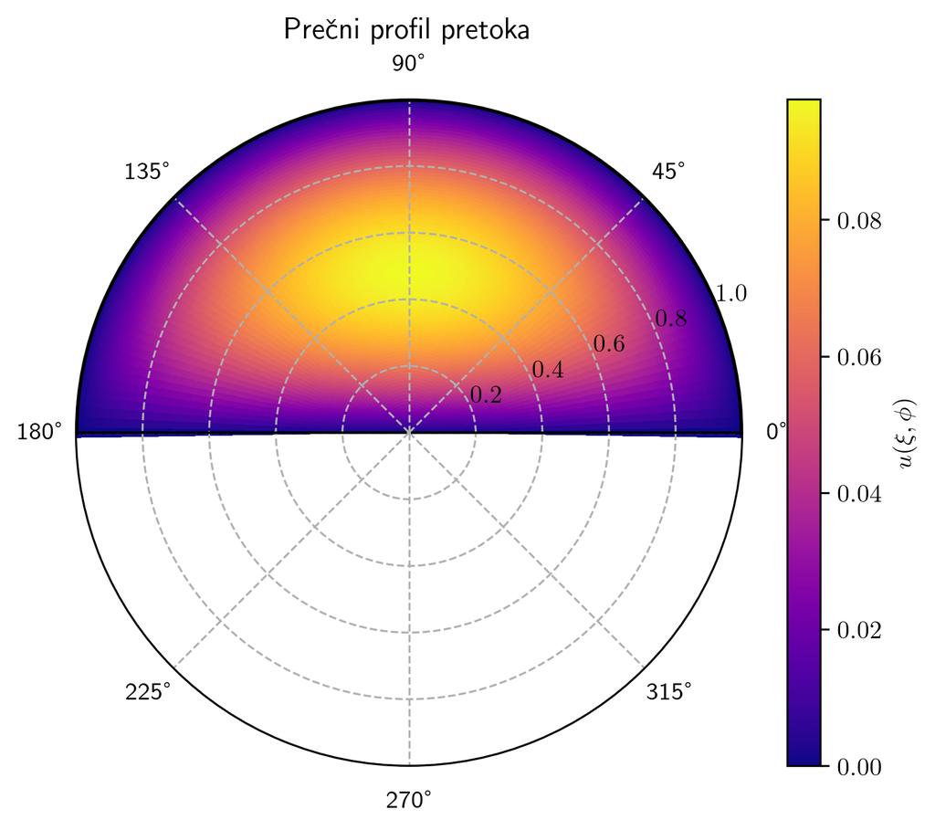

## Zaključek

V nalogi smo izračunali koeficient pretoka za polkrožno cev z uporabo Galerkinove metode. Pri tem smo namesto zahtevnih lastnih funkcij uporabili preprostejše poskusne funkcije, ki zadostijo robnim pogojem. Rezultati kažejo na relativno hitro konvergenco. Kljub relativni enostavnosti rešitve je metoda kar precej robustna.

Luka Skeledžija, [Github source 🔗](https://github.com/lukaske/mafijski-praktikum/tree/main/MFPR/11_galerkin), 2024